# Installing R and RStudio for data analysis

## Install R

#### Step 1: Download R

Visit the [CRAN website](https://cran.r-project.org/) to download R.

[figure not shown]

#### Step 2: Choose Your Operating System

Select the appropriate version for your operating system (Windows, macOS, or Linux).

#### Step 3: Install R

**Windows:** Choose the option *base* as well as *Rtools* (Downloading R for the first time) - you will especially need *Rtools* in later modules.

Run the downloaded executable file and follow the installation instructions.

**macOS:** Download the .pkg file from Latest releases most suitable to your Mac version, and follow the installation instructions.

## Install RStudio

RStudio provides you with tools like code editor with highlighting, project management, version control, package building, debugger, profiler and more.

#### Step 1: Download RStudio

Visit the [RStudio Download page](https://posit.co/download/rstudio-desktop/) to download RStudio.

#### Step 2: Choose Your Version

Select the version of RStudio Desktop that is compatible with your operating system.

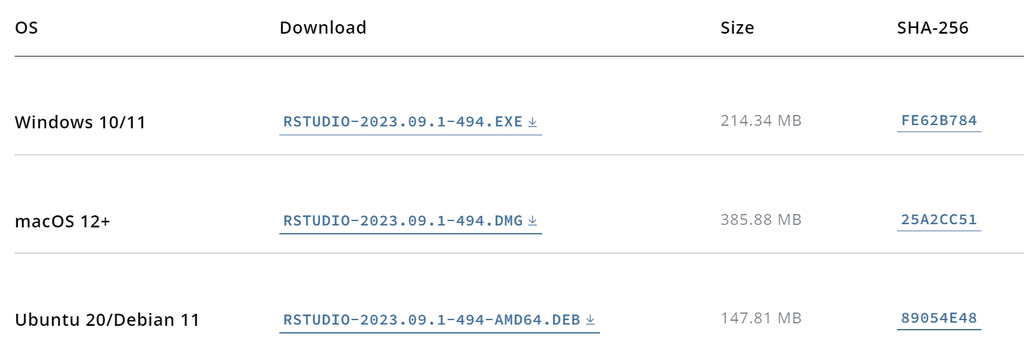

#### Step 3: Install RStudio

**Windows:** Run the downloaded installer and follow the installation instructions.

**macOS:** Drag the RStudio application to your Applications folder.

## Verify your installations

#### Step 1: Open R

**Windows:** Open R from the Start menu.

**macOS:** Open R from your Applications folder.

#### Step 2: Open RStudio

**Windows and macOS:** Open RStudio by clicking on the RStudio icon or running the executable.

Congratulations! You have successfully installed both R and RStudio. You are now ready to explore the world of statistical computing and data analysis.